# Project: TMDb movie data analysis

- Introduction
- Data Wrangling
- Exploratory Data Analysis
- Conclusions

This project use **tmdb-movies.csv** dataset.

## Introduction

This data set contains information about 10,000 movies collected from The Movie Database (TMDb), including user ratings and revenue.

**The first question is:** Which genres are most popular from year to year?

With this question I want to see the most popular genre by it's mean in each year, and at the end see the genre with the most popularity of all of those.

**The Second question is:** What kinds of properties are associated with movies that have high revenues?

With this question I want to see, how much is the difference between movies that have high revenues and normal ones by it's propeties.

```python
import numpy as np
import pandas as pd
import matplotlib.pyplot as plt
import seaborn as sns
import matplotlib.colors as color
import matplotlib.cm as cm
%matplotlib inline
```

## Data Wrangling

### General Properties

```python
df = pd.read_csv('tmdb-movies.csv')
df.head()
```

|  | id | imdb_id | popularity | budget | revenue | original_title | cast | homepage | director | tagline | ... | overview | runtime | genres | production_companies | release_date | vote_count | vote_average | release_year | budget_adj | revenue_adj |
| --- | --- | --- | --- | --- | --- | --- | --- | --- | --- | --- | --- | --- | --- | --- | --- | --- | --- | --- | --- | --- | --- |
| 0 | 135397 | tt0369610 | 32.985763 | 150000000 | 1513528810 | Jurassic World | Chris Pratt\|Bryce Dallas Howard\|Irrfan Khan\|Vi... | http://www.jurassicworld.com/ | Colin Trevorrow | The park is open. | ... | Twenty-two years after the events of Jurassic ... | 124 | Action\|Adventure\|Science Fiction\|Thriller | Universal Studios\|Amblin Entertainment\|Legenda... | 6/9/15 | 5562 | 6.5 | 2015 | 1.379999e+08 | 1.392446e+09 |
| 1 | 76341 | tt1392190 | 28.419936 | 150000000 | 378436354 | Mad Max: Fury Road | Tom Hardy\|Charlize Theron\|Hugh Keays-Byrne\|Nic... | http://www.madmaxmovie.com/ | George Miller | What a Lovely Day. | ... | An apocalyptic story set in the furthest reach... | 120 | Action\|Adventure\|Science Fiction\|Thriller | Village Roadshow Pictures\|Kennedy Miller Produ... | 5/13/15 | 6185 | 7.1 | 2015 | 1.379999e+08 | 3.481613e+08 |
| 2 | 262500 | tt2908446 | 13.112507 | 110000000 | 295238201 | Insurgent | Shailene Woodley\|Theo James\|Kate Winslet\|Ansel... | http://www.thedivergentseries.movie/#insurgent | Robert Schwentke | One Choice Can Destroy You | ... | Beatrice Prior must confront her inner demons ... | 119 | Adventure\|Science Fiction\|Thriller | Summit Entertainment\|Mandeville Films\|Red Wago... | 3/18/15 | 2480 | 6.3 | 2015 | 1.012000e+08 | 2.716190e+08 |
| 3 | 140607 | tt2488496 | 11.173104 | 200000000 | 2068178225 | Star Wars: The Force Awakens | Harrison Ford\|Mark Hamill\|Carrie Fisher\|Adam D... | http://www.starwars.com/films/star-wars-episod... | J.J. Abrams | Every generation has a story. | ... | Thirty years after defeating the Galactic Empi... | 136 | Action\|Adventure\|Science Fiction\|Fantasy | Lucasfilm\|Truenorth Productions\|Bad Robot | 12/15/15 | 5292 | 7.5 | 2015 | 1.839999e+08 | 1.902723e+09 |
| 4 | 168259 | tt2820852 | 9.335014 | 190000000 | 1506249360 | Furious 7 | Vin Diesel\|Paul Walker\|Jason Statham\|Michelle ... | http://www.furious7.com/ | James Wan | Vengeance Hits Home | ... | Deckard Shaw seeks revenge against Dominic Tor... | 137 | Action\|Crime\|Thriller | Universal Pictures\|Original Film\|Media Rights ... | 4/1/15 | 2947 | 7.3 | 2015 | 1.747999e+08 | 1.385749e+09 |

5 rows × 21 columns

```python
df.shape
```

```
(10866, 21)
```

```python
df.info()
```

```
<class 'pandas.core.frame.DataFrame'>
RangeIndex: 10866 entries, 0 to 10865
Data columns (total 21 columns):
id                      10866 non-null int64
imdb_id                 10856 non-null object
popularity              10866 non-null float64
budget                  10866 non-null int64
revenue                 10866 non-null int64
original_title          10866 non-null object
cast                    10790 non-null object
homepage                2936 non-null object
director                10822 non-null object
tagline                 8042 non-null object
keywords                9373 non-null object
overview                10862 non-null object
runtime                 10866 non-null int64
genres                  10843 non-null object
production_companies    9836 non-null object
release_date            10866 non-null object
vote_count              10866 non-null int64
vote_average            10866 non-null float64
release_year            10866 non-null int64
budget_adj              10866 non-null float64
revenue_adj             10866 non-null float64
dtypes: float64(4), int64(6), object(11)
memory usage: 1.7+ MB
```

```python
df.describe()
```

|  | id | popularity | budget | revenue | runtime | vote_count | vote_average | release_year | budget_adj | revenue_adj |
| --- | --- | --- | --- | --- | --- | --- | --- | --- | --- | --- |
| count | 10866.000000 | 10866.000000 | 1.086600e+04 | 1.086600e+04 | 10866.000000 | 10866.000000 | 10866.000000 | 10866.000000 | 1.086600e+04 | 1.086600e+04 |
| mean | 66064.177434 | 0.646441 | 1.462570e+07 | 3.982332e+07 | 102.070863 | 217.389748 | 5.974922 | 2001.322658 | 1.755104e+07 | 5.136436e+07 |
| std | 92130.136561 | 1.000185 | 3.091321e+07 | 1.170035e+08 | 31.381405 | 575.619058 | 0.935142 | 12.812941 | 3.430616e+07 | 1.446325e+08 |
| min | 5.000000 | 0.000065 | 0.000000e+00 | 0.000000e+00 | 0.000000 | 10.000000 | 1.500000 | 1960.000000 | 0.000000e+00 | 0.000000e+00 |
| 25% | 10596.250000 | 0.207583 | 0.000000e+00 | 0.000000e+00 | 90.000000 | 17.000000 | 5.400000 | 1995.000000 | 0.000000e+00 | 0.000000e+00 |
| 50% | 20669.000000 | 0.383856 | 0.000000e+00 | 0.000000e+00 | 99.000000 | 38.000000 | 6.000000 | 2006.000000 | 0.000000e+00 | 0.000000e+00 |
| 75% | 75610.000000 | 0.713817 | 1.500000e+07 | 2.400000e+07 | 111.000000 | 145.750000 | 6.600000 | 2011.000000 | 2.085325e+07 | 3.369710e+07 |
| max | 417859.000000 | 32.985763 | 4.250000e+08 | 2.781506e+09 | 900.000000 | 9767.000000 | 9.200000 | 2015.000000 | 4.250000e+08 | 2.827124e+09 |

```python
na_genre = df.genres.isna()
df[na_genre].tail(10)
```

|  | id | imdb_id | popularity | budget | revenue | original_title | cast | homepage | director | tagline | ... | overview | runtime | genres | production_companies | release_date | vote_count | vote_average | release_year | budget_adj | revenue_adj |
| --- | --- | --- | --- | --- | --- | --- | --- | --- | --- | --- | --- | --- | --- | --- | --- | --- | --- | --- | --- | --- | --- |
| 5830 | 282848 | tt2986512 | 0.248944 | 0 | 0 | Doctor Who: The Time of the Doctor | Matt Smith\|Jenna Coleman | NaN | James Payne | A change is going to come... | ... | Orbiting a quiet backwater planet, the massed ... | 60 | NaN | NaN | 12/25/13 | 26 | 8.5 | 2013 | 0.00000 | 0.0 |
| 5934 | 200204 | tt2808968 | 0.067433 | 0 | 0 | Prada: Candy | Peter Gadiot\|Rodolphe Pauly\|LÃ©a Seydoux | NaN | Wes Anderson\|Roman Coppola | short | ... | Candy is a modern chic french woman. She meets... | 3 | NaN | NaN | 3/25/13 | 27 | 6.9 | 2013 | 0.00000 | 0.0 |
| 6043 | 190940 | tt2797242 | 0.039080 | 0 | 0 | Bombay Talkies | Aamir Khan\|Rani Mukerji\|Randeep Hooda\|Saqib Sa... | http://en.wikipedia.org/wiki/Bombay_Talkies_%2... | Anurag Kashyap\|Dibakar Banerjee\|Zoya Akhtar\|Ka... | NaN | ... | One hundred years of Hindi cinema is celebrate... | 127 | NaN | Viacom 18 Motion Pictures | 5/3/13 | 12 | 5.9 | 2013 | 0.00000 | 0.0 |
| 6530 | 168891 | tt0818519 | 0.092724 | 0 | 0 | Saw Rebirth | Whit Anderson\|Stan Kirsch\|Jeff Shuter\|George W... | NaN | Jeff Shuter\|Daniel Viney | Somewhere... Somehow... Something went wrong... | ... | This comic, set in the world of SAW goes back ... | 6 | NaN | NaN | 10/24/05 | 24 | 5.9 | 2005 | 0.00000 | 0.0 |
| 8234 | 56804 | tt0114844 | 0.028874 | 0 | 0 | Viaggi di nozze | Carlo Verdone\|Claudia Gerini\|Veronica Pivetti\|... | NaN | Carlo Verdone | NaN | ... | Le vicessitudini di tre coppie di novelli spos... | 103 | NaN | NaN | 12/15/95 | 44 | 6.7 | 1995 | 0.00000 | 0.0 |
| 8614 | 65595 | tt0117880 | 0.273934 | 0 | 0 | T2 3-D: Battle Across Time | Arnold Schwarzenegger\|Linda Hamilton\|Edward Fu... | NaN | James Cameron | NaN | ... | Three freedom fighters attack a large corporat... | 12 | NaN | NaN | 1/1/96 | 14 | 6.7 | 1996 | 0.00000 | 0.0 |
| 8878 | 92208 | tt0250593 | 0.038045 | 0 | 0 | Mom's Got a Date With a Vampire | Matt O'Leary\|Laura Vandervoort\|Myles Jeffrey\|C... | NaN | Steve Boyum | NaN | ... | The Hansen kids are in a jam. Adam and his bes... | 85 | NaN | Walt Disney Pictures | 10/13/00 | 16 | 5.4 | 2000 | 0.00000 | 0.0 |
| 9307 | 141859 | tt0097446 | 0.094652 | 0 | 0 | Goldeneye | Charles Dance\|Phyllis Logan\|Patrick Ryecart\|La... | NaN | Don Boyd | NaN | ... | Fact-based biography of James Bond author, Ian... | 105 | NaN | Anglia Television | 8/26/89 | 10 | 5.3 | 1989 | 0.00000 | 0.0 |
| 9799 | 48847 | tt0193716 | 0.175008 | 0 | 0 | The Amputee | Catherine E. Coulson\|David Lynch | NaN | David Lynch | NaN | ... | A double leg amputated woman sits and writes a... | 5 | NaN | NaN | 1/1/74 | 11 | 5.0 | 1974 | 0.00000 | 0.0 |
| 10659 | 4255 | tt0065904 | 0.344172 | 5000 | 0 | The Party at Kitty and Stud's | Sylvester Stallone\|Henrietta Holm\|Nicholas War... | NaN | Morton Lewis | NaN | ... | Kitty and Stud are lovers. They enjoy a robust... | 71 | NaN | Stallion Releasing Inc. | 2/10/70 | 10 | 3.0 | 1970 | 28081.84172 | 0.0 |

10 rows × 21 columns

**There's not to much correlation with no genre movies with other variables**

```python
na_companies = df.production_companies.isna()
df[na_companies].head(10)
```

|  | id | imdb_id | popularity | budget | revenue | original_title | cast | homepage | director | tagline | ... | overview | runtime | genres | production_companies | release_date | vote_count | vote_average | release_year | budget_adj | revenue_adj |
| --- | --- | --- | --- | --- | --- | --- | --- | --- | --- | --- | --- | --- | --- | --- | --- | --- | --- | --- | --- | --- | --- |
| 228 | 300792 | tt1618448 | 0.584363 | 0 | 0 | Racing Extinction | Elon Musk\|Jane Goodall\|Louie Psihoyos\|Leilani ... | http://www.racingextinction.com | Louie Psihoyos | It's better to light one candle than curse the... | ... | An unlikely team of activists and innovators h... | 90 | Adventure\|Documentary | NaN | 1/24/15 | 36 | 7.8 | 2015 | 0.000000e+00 | 0.000000e+00 |
| 259 | 360603 | tt5133572 | 0.476341 | 0 | 0 | Crown for Christmas | Danica McKellar\|Rupert Penry-Jones\|Ellie Botte... | NaN | Alex Zamm | NaN | ... | After getting fired from her job as a maid at ... | 84 | TV Movie | NaN | 11/27/15 | 10 | 7.6 | 2015 | 0.000000e+00 | 0.000000e+00 |
| 295 | 363483 | tt5133810 | 0.417191 | 0 | 0 | 12 Gifts of Christmas | Katrina Law\|Donna Mills\|Aaron O'Connell\|Melani... | NaN | Peter Sullivan | NaN | ... | When Anna Parisi, an unemployed fine arts pain... | 84 | Family\|TV Movie | NaN | 11/26/15 | 12 | 6.3 | 2015 | 0.000000e+00 | 0.000000e+00 |
| 298 | 354220 | tt3826866 | 0.370258 | 0 | 0 | The Girl in the Photographs | Kal Penn\|Claudia Lee\|Kenny Wormald\|Toby Heming... | NaN | Nick Simon | NaN | ... | Images coming from the crimes committed by a d... | 95 | Crime\|Horror\|Thriller | NaN | 9/14/15 | 10 | 4.7 | 2015 | 0.000000e+00 | 0.000000e+00 |
| 328 | 308457 | tt3090670 | 0.367617 | 0 | 0 | Advantageous | Jacqueline Kim\|James Urbaniak\|Freya Adams\|Ken ... | NaN | Jennifer Phang | NaN | ... | In a near-future city where soaring opulence o... | 92 | Science Fiction\|Drama\|Family | NaN | 6/23/15 | 29 | 6.4 | 2015 | 0.000000e+00 | 0.000000e+00 |
| 370 | 318279 | tt2545428 | 0.314199 | 0 | 2334228 | Meru | Conrad Anker\|Grace Chin\|Jimmy Chin\|Amee Hinkley | http://www.merufilm.com/ | Jimmy Chin\|Elizabeth Chai Vasarhelyi | NaN | ... | Meru is the electrifying story of three elite ... | 89 | Adventure\|Documentary | NaN | 1/25/15 | 42 | 6.9 | 2015 | 0.000000e+00 | 2.147489e+06 |
| 374 | 206197 | tt1015471 | 0.302474 | 0 | 0 | The Sisterhood of Night | Kara Hayward\|Georgie Henley\|Olivia DeJonge\|Lau... | http://www.thesisterhoodofnight-movie.com/ | Caryn Waechter | The Salem Witch Trials remixed. | ... | When a teenage girl says she's the victim of a... | 104 | Mystery\|Drama\|Thriller | NaN | 4/10/15 | 25 | 6.6 | 2015 | 0.000000e+00 | 0.000000e+00 |
| 382 | 306197 | tt4145304 | 0.295946 | 0 | 0 | Unexpected | Cobie Smulders\|Gail Bean\|Anders Holm\|Elizabeth... | NaN | Kris Swanberg | No one is ever really prepared. | ... | An inner-city high school teacher discovers sh... | 90 | Drama\|Comedy | NaN | 7/24/15 | 22 | 5.7 | 2015 | 0.000000e+00 | 0.000000e+00 |
| 388 | 323967 | tt2016335 | 0.289526 | 700000 | 0 | Walter | Andrew J. West\|Justin Kirk\|Virginia Madsen\|Wil... | NaN | Anna Mastro | Heaven or hell. It's in his hands. | ... | A ticket-taker at the local cinema believes he... | 87 | Drama\|Comedy | NaN | 3/13/15 | 12 | 5.2 | 2015 | 6.439997e+05 | 0.000000e+00 |
| 393 | 343284 | tt3602128 | 0.283194 | 2000000 | 0 | Night Of The Living Deb | Maria Thayer\|Chris Marquette\|Ray Wise\|Michael ... | NaN | Kyle Rankin | NaN | ... | After a one night stand Deb wakes up in the mi... | 85 | Comedy\|Horror | NaN | 8/29/15 | 13 | 5.7 | 2015 | 1.839999e+06 | 0.000000e+00 |

10 rows × 21 columns

```python
df[na_companies].tail(10)
```

|  | id | imdb_id | popularity | budget | revenue | original_title | cast | homepage | director | tagline | ... | overview | runtime | genres | production_companies | release_date | vote_count | vote_average | release_year | budget_adj | revenue_adj |
| --- | --- | --- | --- | --- | --- | --- | --- | --- | --- | --- | --- | --- | --- | --- | --- | --- | --- | --- | --- | --- | --- |
| 10592 | 38343 | tt0092276 | 0.001567 | 0 | 0 | Yuppies 2 | Massimo Boldi\|Jerry CalÃ \|Christian De Sica\|Ez... | NaN | Enrico Oldoini | NaN | ... | Continuano le avventure degli yuppies milanesi... | 104 | Comedy | NaN | 1/1/86 | 11 | 5.0 | 1986 | 0.0 | 0.000000e+00 |
| 10723 | 29067 | tt0059465 | 0.004770 | 0 | 0 | Die, Monster, Die! | Boris Karloff\|Nick Adams\|Freda Jackson\|Suzan F... | NaN | Daniel Haller | No one can stop this killing machine....It's A... | ... | A young man visits his fiancÃ©'s estate to dis... | 80 | Drama\|Horror\|Thriller\|Science Fiction\|Foreign | NaN | 10/26/65 | 10 | 6.4 | 1965 | 0.0 | 0.000000e+00 |
| 10741 | 28289 | tt0064117 | 0.305709 | 0 | 0 | Cactus Flower | Walter Matthau\|Ingrid Bergman\|Goldie Hawn\|Jack... | NaN | Gene Saks | The prickly stage success that convulsed audie... | ... | Distraught when her middle-aged lover breaks a... | 103 | Comedy\|Romance | NaN | 12/16/69 | 19 | 6.8 | 1969 | 0.0 | 0.000000e+00 |
| 10754 | 3171 | tt0064064 | 0.002757 | 0 | 0 | Bambi Meets Godzilla | NaN | NaN | Marv Newland | NaN | ... | Bambi is nibbling the grass, unaware of the up... | 2 | Animation\|Comedy | NaN | 1/1/69 | 12 | 5.6 | 1969 | 0.0 | 0.000000e+00 |
| 10787 | 14822 | tt0078158 | 0.282763 | 0 | 16393000 | Return From Witch Mountain | Bette Davis\|Christopher Lee\|Kim Richards\|Ike E... | NaN | John Hough | Sinister forces from this world against two yo... | ... | In this sequal to "Escape From Witch Mountain,... | 95 | Adventure\|Fantasy\|Science Fiction\|Family | NaN | 3/10/78 | 22 | 5.8 | 1978 | 0.0 | 5.479689e+07 |
| 10804 | 15867 | tt0077742 | 0.149259 | 0 | 0 | Interiors | Diane Keaton\|Kristin Griffith\|Mary Beth Hurt\|R... | NaN | Woody Allen | NaN | ... | Homage to Ingmar Bergman in this family drama ... | 93 | Drama | NaN | 8/2/78 | 35 | 6.3 | 1978 | 0.0 | 0.000000e+00 |
| 10806 | 24998 | tt0077598 | 0.138635 | 0 | 0 | Gates of Heaven | Lucille Billingsley\|Zella Graham\|Cal Harberts\|... | NaN | Errol Morris | Death is for the living and not for the dead s... | ... | The men who run a pet cemetery, and the men an... | 85 | Documentary | NaN | 10/1/78 | 12 | 5.9 | 1978 | 0.0 | 0.000000e+00 |
| 10816 | 16378 | tt0077147 | 0.064602 | 0 | 0 | The Rutles: All You Need Is Cash | Eric Idle\|John Halsey\|Ricky Fataar\|Neil Innes\|... | NaN | Eric Idle\|Gary Weis | NaN | ... | The story of the rise and fall of the Pre-Fab ... | 76 | Comedy | NaN | 3/22/78 | 14 | 6.0 | 1978 | 0.0 | 0.000000e+00 |
| 10842 | 36540 | tt0061199 | 0.253437 | 0 | 0 | Winnie the Pooh and the Honey Tree | Sterling Holloway\|Junius Matthews\|Sebastian Ca... | NaN | Wolfgang Reitherman | NaN | ... | Christopher Robin's bear attempts to raid a be... | 25 | Animation\|Family | NaN | 1/1/66 | 12 | 7.9 | 1966 | 0.0 | 0.000000e+00 |
| 10853 | 15598 | tt0060086 | 0.163592 | 0 | 0 | Alfie | Michael Caine\|Shelley Winters\|Millicent Martin... | NaN | Lewis Gilbert | Is any man an Alfie? Ask any girl! | ... | The film tells the story of a young man who le... | 114 | Comedy\|Drama\|Romance | NaN | 3/29/66 | 26 | 6.2 | 1966 | 0.0 | 0.000000e+00 |

10 rows × 21 columns

**There's not to much correlation with no production companies movies with other variables**

```python
na_director = df.director.isna()
df[na_director].head(10)
```

|  | id | imdb_id | popularity | budget | revenue | original_title | cast | homepage | director | tagline | ... | overview | runtime | genres | production_companies | release_date | vote_count | vote_average | release_year | budget_adj | revenue_adj |
| --- | --- | --- | --- | --- | --- | --- | --- | --- | --- | --- | --- | --- | --- | --- | --- | --- | --- | --- | --- | --- | --- |
| 532 | 320996 | tt4073952 | 0.126594 | 0 | 0 | Iliza Shlesinger: Freezing Hot | Iliza Shlesinger | http://www.iliza.com/freezing-hot.html | NaN | NaN | ... | Smart and brazen comedian Iliza Shlesinger sha... | 71 | Comedy | New Wave Entertainment | 1/23/15 | 14 | 6.6 | 2015 | 0.000000e+00 | 0.0 |
| 548 | 355131 | NaN | 0.108072 | 0 | 0 | Sense8: Creating the World | Tuppence Middleton\|Bae Doona \|Brian J. Smith\|A... | NaN | NaN | NaN | ... | NaN | 25 | Documentary\|Science Fiction | Netflix | 8/10/15 | 12 | 7.5 | 2015 | 0.000000e+00 | 0.0 |
| 556 | 321160 | tt3908634 | 0.100910 | 0 | 0 | With This Ring | Regina Hall\|Jill Scott\|Eve\|Brooklyn Sudano\|Dei... | http://www.mylifetime.com/movies/with-this-ring | NaN | NaN | ... | After attending their friend Elise's (Sudano) ... | 105 | Comedy\|Romance | Lifetime Television\|Sony Pictures Television | 1/24/15 | 14 | 6.5 | 2015 | 0.000000e+00 | 0.0 |
| 1032 | 259910 | tt3591568 | 0.291253 | 0 | 0 | Marvel Studios: Assembling a Universe | Robert Downey Jr.\|Chris Hemsworth\|Chris Evans\|... | NaN | NaN | - | ... | A look at the story behind Marvel Studios and ... | 43 | TV Movie\|Documentary | Marvel Studios\|ABC Studios | 3/18/14 | 32 | 6.3 | 2014 | 0.000000e+00 | 0.0 |
| 1054 | 253675 | tt3711030 | 0.269468 | 0 | 0 | Unlocking Sherlock | Benedict Cumberbatch\|Martin Freeman\|Steven Mof... | NaN | NaN | NaN | ... | Explore how writers Steven Moffat and Mark Gat... | 60 | TV Movie\|Documentary | NaN | 1/19/14 | 11 | 7.2 | 2014 | 0.000000e+00 | 0.0 |
| 1203 | 256561 | tt3203290 | 0.119891 | 150000 | 0 | Free to Play | Benedict Lim\|Danil Ishutin\|Clinton Loomis | http://www.freetoplaythemovie.com | NaN | One game will change their lives. | ... | Follow three professional video game players a... | 75 | Documentary | Valve | 3/19/14 | 40 | 7.0 | 2014 | 1.381637e+05 | 0.0 |
| 1241 | 296370 | tt3024964 | 0.135376 | 0 | 0 | Dance-Off | Kathryn McCormick\|Shane Harper\|Finola Hughes\|C... | NaN | NaN | NaN | ... | DANCE-OFF is a tongue-in-cheek family comedy s... | 0 | Romance\|Music\|Comedy | NaN | 1/1/14 | 18 | 5.7 | 2014 | 0.000000e+00 | 0.0 |
| 1288 | 301235 | tt4217172 | 0.038364 | 0 | 0 | Top Gear: The Perfect Road Trip 2 | Jeremy Clarkson\|Richard Hammond | NaN | NaN | NaN | ... | In 2013 Jeremy Clarkson and Richard Hammond em... | 94 | Documentary | 2 Entertain Video | 11/17/14 | 12 | 6.8 | 2014 | 0.000000e+00 | 0.0 |
| 1852 | 133365 | tt1127205 | 0.256703 | 0 | 0 | The Diary of Anne Frank | Ellie Kendrick\|Kate Ashfield\|Geoff Breton\|Feli... | NaN | NaN | NaN | ... | Called the most accurate adaptation of Anne Fr... | 100 | Drama | Darlow Smithson Productions\|British Broadcasti... | 1/9/09 | 19 | 7.5 | 2009 | 0.000000e+00 | 0.0 |
| 1872 | 26379 | tt1532957 | 0.091395 | 3250000 | 0 | Paa | Amitabh Bachchan\|Abhishek Bachchan\|Vidya Balan... | http://www.paathefilm.com/ | NaN | NaN | ... | He suffers from a progeria like syndrome. Ment... | 133 | Drama\|Family\|Foreign | A B Corp | 12/4/09 | 11 | 6.1 | 2009 | 3.303301e+06 | 0.0 |

10 rows × 21 columns

```python
df[na_director].tail(10)
```

|  | id | imdb_id | popularity | budget | revenue | original_title | cast | homepage | director | tagline | ... | overview | runtime | genres | production_companies | release_date | vote_count | vote_average | release_year | budget_adj | revenue_adj |
| --- | --- | --- | --- | --- | --- | --- | --- | --- | --- | --- | --- | --- | --- | --- | --- | --- | --- | --- | --- | --- | --- |
| 5915 | 284019 | tt2283584 | 0.168210 | 0 | 0 | Phineas and Ferb: Mission Marvel | Vincent Martella\|Thomas Brodie-Sangster\|Ashley... | http://disneyxd.disney.com/phineas-and-ferb/mi... | NaN | Avengers need Phineas and Ferb to Assemble. | ... | When Dr. Doofenshmirtz's latest invention caus... | 44 | Action\|Adventure\|Science Fiction | Disney Television Animation | 8/16/13 | 13 | 5.9 | 2013 | 0.0 | 0.0 |
| 5972 | 238234 | tt3258142 | 0.165605 | 0 | 0 | Top Gear: The Perfect Road Trip | Jeremy Clarkson\|Richard Hammond | NaN | NaN | Seven days, more than 1,000 miles, 20 cars, tw... | ... | The aim: to select the ideal mode of transport... | 84 | TV Movie\|Action\|Adventure\|Documentary | BBC | 11/17/13 | 35 | 7.6 | 2013 | 0.0 | 0.0 |
| 6033 | 238185 | tt3397430 | 0.048587 | 0 | 0 | Russell Brand: Messiah Complex | Russell Brand | http://www.russellbrand.com/2013/11/messiah-co... | NaN | NaN | ... | Recorded live at Hammersmith Apollo, Russell q... | 99 | Comedy | NaN | 11/25/13 | 12 | 6.8 | 2013 | 0.0 | 0.0 |
| 6181 | 18729 | tt0088583 | 0.000065 | 0 | 0 | North and South, Book I | Patrick Swayze\|Philip Casnoff\|Kirstie Alley\|Ge... | NaN | NaN | NaN | ... | Two friends, one northern and one southern, st... | 561 | Drama\|History\|Western | NaN | 11/3/85 | 17 | 6.0 | 1985 | 0.0 | 0.0 |
| 7579 | 58432 | tt0484273 | 0.443952 | 0 | 0 | La hora fría | Silke\|Omar Muñoz\|Pepo Oliva\|Carola Manzanares... | NaN | NaN | NaN | ... | The eight years boy Jesús has been living in ... | 92 | Horror\|Thriller\|Science Fiction\|Mystery\|Foreign | NaN | 9/14/07 | 10 | 4.9 | 2007 | 0.0 | 0.0 |
| 7767 | 282758 | tt0827573 | 0.126603 | 0 | 0 | Doctor Who: The Runaway Bride | David Tennant\|Catherine Tate | NaN | NaN | NaN | ... | A young bride in the midst of her wedding find... | 60 | Science Fiction\|TV Movie | NaN | 7/6/07 | 18 | 7.6 | 2007 | 0.0 | 0.0 |
| 7814 | 25565 | tt1236486 | 0.040311 | 0 | 0 | Transformers: Beginnings | Peter Cullen\|Frank Welker\|Mark Ryan\|Patrick Ha... | NaN | NaN | NaN | ... | On their home planet of Cybertron, the Autobot... | 22 | Animation\|Action\|Thriller\|Science Fiction | DreamWorks Home Entertainment | 10/16/07 | 34 | 5.8 | 2007 | 0.0 | 0.0 |
| 9593 | 46188 | tt0220698 | 0.001662 | 0 | 0 | Peter Pan | NaN | NaN | NaN | NaN | ... | This animated fairy tale for kids tells the cl... | 52 | Action\|Adventure\|Animation\|Family\|Fantasy | Burbank Films Australia | 1/1/88 | 28 | 6.6 | 1988 | 0.0 | 0.0 |
| 10386 | 225804 | tt1028555 | 0.118854 | 0 | 0 | The Making of 'The Nightmare Before Christmas' | Mike Belzer\|Tim Burton\|Bonita DeCarlo\|Greg Dyk... | NaN | NaN | NaN | ... | The Making of Tim Burton and Henry Selick's 19... | 25 | Documentary | Buena Vista Home Entertainment | 10/3/93 | 15 | 7.5 | 1993 | 0.0 | 0.0 |
| 10426 | 34038 | tt0061937 | 0.114034 | 0 | 0 | Magical Mystery Tour | John Lennon\|Paul McCartney\|George Harrison\|Rin... | NaN | NaN | NaN | ... | A typically Beatlesque film originally produce... | 55 | Music | MPI Home Video | 12/25/67 | 15 | 5.8 | 1967 | 0.0 | 0.0 |

10 rows × 21 columns

**There's not to much correlation with no director movies with other variables**

### Data Cleaning

**Removing those columns because they are not needed for the analisys.**

```python
df.drop(['id', 'homepage', 'imdb_id','tagline', 'keywords', 'overview'], axis=1, inplace=True)
```

```python
df.info()
```

```
<class 'pandas.core.frame.DataFrame'>
RangeIndex: 10866 entries, 0 to 10865
Data columns (total 15 columns):
popularity              10866 non-null float64
budget                  10866 non-null int64
revenue                 10866 non-null int64
original_title          10866 non-null object
cast                    10790 non-null object
director                10822 non-null object
runtime                 10866 non-null int64
genres                  10843 non-null object
production_companies    9836 non-null object
release_date            10866 non-null object
vote_count              10866 non-null int64
vote_average            10866 non-null float64
release_year            10866 non-null int64
budget_adj              10866 non-null float64
revenue_adj             10866 non-null float64
dtypes: float64(4), int64(5), object(6)
memory usage: 1.2+ MB
```

```python
df.head()
```

|  | popularity | budget | revenue | original_title | cast | director | runtime | genres | production_companies | release_date | vote_count | vote_average | release_year | budget_adj | revenue_adj |
| --- | --- | --- | --- | --- | --- | --- | --- | --- | --- | --- | --- | --- | --- | --- | --- |
| 0 | 32.985763 | 150000000 | 1513528810 | Jurassic World | Chris Pratt\|Bryce Dallas Howard\|Irrfan Khan\|Vi... | Colin Trevorrow | 124 | Action\|Adventure\|Science Fiction\|Thriller | Universal Studios\|Amblin Entertainment\|Legenda... | 6/9/15 | 5562 | 6.5 | 2015 | 1.379999e+08 | 1.392446e+09 |
| 1 | 28.419936 | 150000000 | 378436354 | Mad Max: Fury Road | Tom Hardy\|Charlize Theron\|Hugh Keays-Byrne\|Nic... | George Miller | 120 | Action\|Adventure\|Science Fiction\|Thriller | Village Roadshow Pictures\|Kennedy Miller Produ... | 5/13/15 | 6185 | 7.1 | 2015 | 1.379999e+08 | 3.481613e+08 |
| 2 | 13.112507 | 110000000 | 295238201 | Insurgent | Shailene Woodley\|Theo James\|Kate Winslet\|Ansel... | Robert Schwentke | 119 | Adventure\|Science Fiction\|Thriller | Summit Entertainment\|Mandeville Films\|Red Wago... | 3/18/15 | 2480 | 6.3 | 2015 | 1.012000e+08 | 2.716190e+08 |
| 3 | 11.173104 | 200000000 | 2068178225 | Star Wars: The Force Awakens | Harrison Ford\|Mark Hamill\|Carrie Fisher\|Adam D... | J.J. Abrams | 136 | Action\|Adventure\|Science Fiction\|Fantasy | Lucasfilm\|Truenorth Productions\|Bad Robot | 12/15/15 | 5292 | 7.5 | 2015 | 1.839999e+08 | 1.902723e+09 |
| 4 | 9.335014 | 190000000 | 1506249360 | Furious 7 | Vin Diesel\|Paul Walker\|Jason Statham\|Michelle ... | James Wan | 137 | Action\|Crime\|Thriller | Universal Pictures\|Original Film\|Media Rights ... | 4/1/15 | 2947 | 7.3 | 2015 | 1.747999e+08 | 1.385749e+09 |

```python
df.describe()
```

|  | popularity | budget | revenue | runtime | vote_count | vote_average | release_year | budget_adj | revenue_adj |
| --- | --- | --- | --- | --- | --- | --- | --- | --- | --- |
| count | 10866.000000 | 1.086600e+04 | 1.086600e+04 | 10866.000000 | 10866.000000 | 10866.000000 | 10866.000000 | 1.086600e+04 | 1.086600e+04 |
| mean | 0.646441 | 1.462570e+07 | 3.982332e+07 | 102.070863 | 217.389748 | 5.974922 | 2001.322658 | 1.755104e+07 | 5.136436e+07 |
| std | 1.000185 | 3.091321e+07 | 1.170035e+08 | 31.381405 | 575.619058 | 0.935142 | 12.812941 | 3.430616e+07 | 1.446325e+08 |
| min | 0.000065 | 0.000000e+00 | 0.000000e+00 | 0.000000 | 10.000000 | 1.500000 | 1960.000000 | 0.000000e+00 | 0.000000e+00 |
| 25% | 0.207583 | 0.000000e+00 | 0.000000e+00 | 90.000000 | 17.000000 | 5.400000 | 1995.000000 | 0.000000e+00 | 0.000000e+00 |
| 50% | 0.383856 | 0.000000e+00 | 0.000000e+00 | 99.000000 | 38.000000 | 6.000000 | 2006.000000 | 0.000000e+00 | 0.000000e+00 |
| 75% | 0.713817 | 1.500000e+07 | 2.400000e+07 | 111.000000 | 145.750000 | 6.600000 | 2011.000000 | 2.085325e+07 | 3.369710e+07 |
| max | 32.985763 | 4.250000e+08 | 2.781506e+09 | 900.000000 | 9767.000000 | 9.200000 | 2015.000000 | 4.250000e+08 | 2.827124e+09 |

**Function to split the string to be multiple values in the same touple to be the number of those values, that way it's easy and faster to manipulate the datas.**

```python
def drop_na_of_a_column(df,column_name):
    df_copy = df.copy()
    df_copy[column_name].dropna(axis=0,inplace=True)
```

```python
"""
Split the string in multiple rows
"""
def split_string_in_multiple_rows(df, column_name, separator = '|'):

    index = df.set_index(df.columns.drop(column_name, 1).tolist())
    reseted_index = index[column_name].str.split(separator, expand=True).stack().reset_index()
    splited_df = reseted_index.rename(columns={0:column_name}).loc[:,df.columns]
    return splited_df
```

**Split the genres values that have multiple, genres in the same tuple to new rows**

```python
drop_na_of_a_column(df, 'genres')
mult_genres = split_string_in_multiple_rows(df,'genres')
mult_genres.shape
```

```
(26960, 15)
```

```python
df.info()
```

```
<class 'pandas.core.frame.DataFrame'>
RangeIndex: 10866 entries, 0 to 10865
Data columns (total 15 columns):
popularity              10866 non-null float64
budget                  10866 non-null int64
revenue                 10866 non-null int64
original_title          10866 non-null object
cast                    10790 non-null object
director                10822 non-null object
runtime                 10866 non-null int64
genres                  10843 non-null object
production_companies    9836 non-null object
release_date            10866 non-null object
vote_count              10866 non-null int64
vote_average            10866 non-null float64
release_year            10866 non-null int64
budget_adj              10866 non-null float64
revenue_adj             10866 non-null float64
dtypes: float64(4), int64(5), object(6)
memory usage: 1.2+ MB
```

## Exploratory Data Analysis

### Research Question: Which genres are most popular from year to year?

```python
genrers_year_group_pop = mult_genres.groupby(['genres','release_year'],as_index=False).popularity.mean()
genrers_year_group_pop.head()
```

|  | genres | release_year | popularity |
| --- | --- | --- | --- |
| 0 | Action | 1960 | 0.590724 |
| 1 | Action | 1961 | 0.365913 |
| 2 | Action | 1962 | 0.708945 |
| 3 | Action | 1963 | 0.951729 |
| 4 | Action | 1964 | 0.813087 |

Function to adjust chart size

```python
def plt_size(width,height):
    plt.rcParams["figure.figsize"] = (width, height)
```

Get all unique years that contains in the data frame

```python
years = df.release_year.unique()
# Make sure that they are in order
years.sort()
```

Get all unique genres that contains in the data frame

```python
genres = mult_genres.genres.unique()
genres.sort()
genres
```

```
array(['Action', 'Adventure', 'Animation', 'Comedy', 'Crime',
       'Documentary', 'Drama', 'Family', 'Fantasy', 'Foreign', 'History',
       'Horror', 'Music', 'Mystery', 'Romance', 'Science Fiction',
       'TV Movie', 'Thriller', 'War', 'Western'], dtype=object)
```

Group by genres and release_year then calculate the mean of the popularity, and finally reset the index, so the dataframe will be well separate.

```python
df_gen_year_mean_pop = mult_genres.groupby(['genres','release_year']).popularity.mean().reset_index()
```

Group by release_year and get the max mean popularity of each year

```python
df_max_pop_by_year = df_gen_year_mean_pop.groupby('release_year').popularity.max()
```

Filter all the data frame that was grouped by data and release_year with have the same popularity with the same mean popularity of the max mean popularity of the year.

```python
df_max_pop_year_by_year = pd.DataFrame()
for year in years:
    max_pop_year = df_max_pop_by_year[year]
    df_to_append = df_gen_year_mean_pop[df_gen_year_mean_pop.popularity==max_pop_year]
    df_max_pop_year_by_year = df_max_pop_year_by_year.append(df_to_append)
```

**Show a chart with the most popularity genre in each year, and it's respective popularity. Receve the chart function as paramter**

```python
colors = ['#00FFFF', '#458B74', '#E3CF57', '#8A2BE2', '#9C661F', '#5F9EA0', '#FF6103',
               '#458B00', '#808A87', '#DC143C', '#CAFF70', '#9932CC', '#F08080', '#8B5F65']
```

```python
def show_max_genrer_year_by_year_chart(plt_chart):
    plt_size(20,5)
    genres_max_year_by_year = df_max_pop_year_by_year.genres.unique()
    fig, ax = plt.subplots()
    for color, genre in enumerate(genres_max_year_by_year):
        data_to_show = df_max_pop_year_by_year[df_max_pop_year_by_year.genres==genre]
        years_to_show = data_to_show.release_year.unique()
        plt_chart(years_to_show, data_to_show.popularity, label=genre, color=colors[color])

    plt.xlabel('Years')
    plt.ylabel('Popularity Mean')
    plt.xticks(rotation='vertical')
    ax.set_xticks(years)
    plt.legend(loc=0);
```

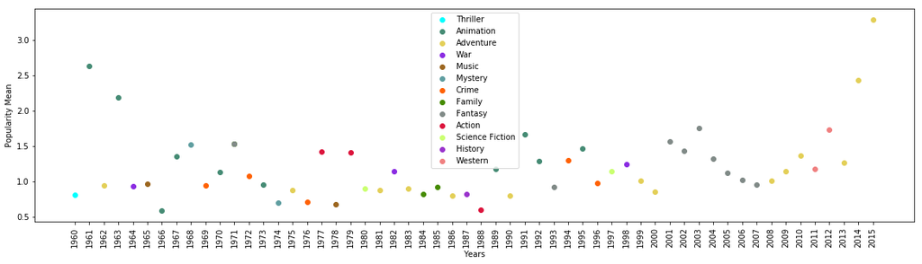

```python
show_max_genrer_year_by_year_chart(plt.scatter)
```

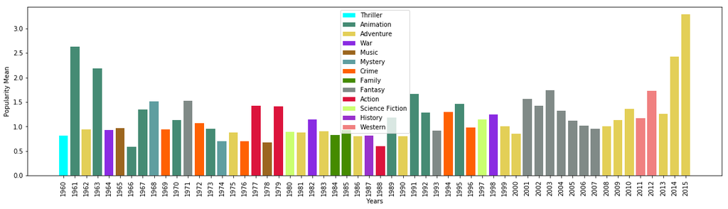

```python
show_max_genrer_year_by_year_chart(plt.bar)
```

**Function to create a pie chart of the sum of the each genres that have the most popularity in each year, with it percent.**

```python
def most_pop_genres_by_year_pie():
    plt_size(15,15)
    fig, ax = plt.subplots()

    df_pie_pop_to_show = df_max_pop_year_by_year.groupby('genres')
    pie_genres_to_show = df_pie_pop_to_show.genres.unique().index

    percent_to_show = []
    data_to_show = df_pie_pop_to_show.popularity.count()
    sum_pie = data_to_show.sum()
    for data in data_to_show:
        percent = (data/sum_pie) * 100
        percent = '{:,.2f} %'.format(percent)
        percent_to_show.append(percent)
    color=iter(cm.rainbow(np.linspace(0,1,len(data_to_show))))
    plt.pie(data_to_show, labels=percent_to_show, colors=colors)

    plt.xlabel('Genres')
    plt.ylabel('Popularity Percent')

    plt.legend(df_pie_pop_to_show.genres.unique().index, loc=0)
    plt.title('Quantity of times each genre is the most popular in each year')
    plt.show();
```

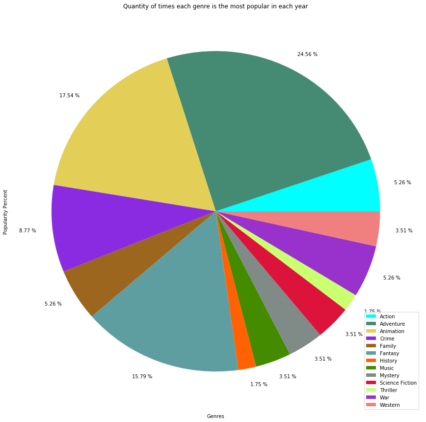

```python
most_pop_genres_by_year_pie()
```

### Research Question: What kinds of properties are associated with movies that have high revenues?

```python
df.query('revenue == 0').shape
```

```
(6016, 15)
```

```python
df_not_zero_revenue = df.query('revenue > 0')
df_not_zero_revenue.describe()
```

|  | popularity | budget | revenue | runtime | vote_count | vote_average | release_year | budget_adj | revenue_adj |
| --- | --- | --- | --- | --- | --- | --- | --- | --- | --- |
| count | 4850.000000 | 4.850000e+03 | 4.850000e+03 | 4850.000000 | 4850.000000 | 4850.000000 | 4850.000000 | 4.850000e+03 | 4.850000e+03 |
| mean | 1.045109 | 2.956970e+07 | 8.922066e+07 | 107.964742 | 436.215876 | 6.148763 | 2000.921649 | 3.516102e+07 | 1.150774e+08 |
| std | 1.356628 | 4.051343e+07 | 1.620684e+08 | 21.112847 | 806.416200 | 0.798795 | 11.569192 | 4.375672e+07 | 1.988419e+08 |
| min | 0.001117 | 0.000000e+00 | 2.000000e+00 | 15.000000 | 10.000000 | 2.100000 | 1960.000000 | 0.000000e+00 | 2.370705e+00 |
| 25% | 0.387754 | 1.700000e+06 | 7.708081e+06 | 95.000000 | 46.000000 | 5.600000 | 1994.000000 | 2.332078e+06 | 1.046262e+07 |
| 50% | 0.680289 | 1.500000e+07 | 3.182654e+07 | 104.000000 | 147.000000 | 6.200000 | 2004.000000 | 2.032801e+07 | 4.392749e+07 |
| 75% | 1.210457 | 4.000000e+07 | 9.991823e+07 | 117.000000 | 435.000000 | 6.700000 | 2010.000000 | 4.973516e+07 | 1.315644e+08 |
| max | 32.985763 | 4.250000e+08 | 2.781506e+09 | 705.000000 | 9767.000000 | 8.400000 | 2015.000000 | 4.250000e+08 | 2.827124e+09 |

```python
df_not_zero_revenue[df_not_zero_revenue.budget==0].corr()
```

|  | popularity | budget | revenue | runtime | vote_count | vote_average | release_year | budget_adj | revenue_adj |
| --- | --- | --- | --- | --- | --- | --- | --- | --- | --- |
| popularity | 1.000000 | NaN | 0.231685 | 0.015938 | 0.685555 | 0.098194 | 0.196054 | NaN | 0.131528 |
| budget | NaN | NaN | NaN | NaN | NaN | NaN | NaN | NaN | NaN |
| revenue | 0.231685 | NaN | 1.000000 | 0.162596 | 0.267191 | 0.015412 | -0.222284 | NaN | 0.888739 |
| runtime | 0.015938 | NaN | 0.162596 | 1.000000 | 0.067332 | 0.165295 | -0.092569 | NaN | 0.158475 |
| vote_count | 0.685555 | NaN | 0.267191 | 0.067332 | 1.000000 | 0.225326 | 0.278090 | NaN | 0.132010 |
| vote_average | 0.098194 | NaN | 0.015412 | 0.165295 | 0.225326 | 1.000000 | 0.026569 | NaN | 0.048976 |
| release_year | 0.196054 | NaN | -0.222284 | -0.092569 | 0.278090 | 0.026569 | 1.000000 | NaN | -0.432834 |
| budget_adj | NaN | NaN | NaN | NaN | NaN | NaN | NaN | NaN | NaN |
| revenue_adj | 0.131528 | NaN | 0.888739 | 0.158475 | 0.132010 | 0.048976 | -0.432834 | NaN | 1.000000 |

```python
budget_zero_replace = df_not_zero_revenue.query('budget != 0').budget.mean()
```

```python
df_not_zero_revenue.budget = df_not_zero_revenue.budget.replace(0, budget_zero_replace)
df_not_zero_revenue.query('budget == 0').shape
```

```
(0, 15)
```

```python
df_not_zero_revenue.query('budget == 0').shape
```

```
(0, 15)
```

```python
df_not_zero_revenue.describe()
```

|  | popularity | budget | revenue | runtime | vote_count | vote_average | release_year | budget_adj | revenue_adj |
| --- | --- | --- | --- | --- | --- | --- | --- | --- | --- |
| count | 4850.000000 | 4.850000e+03 | 4.850000e+03 | 4850.000000 | 4850.000000 | 4850.000000 | 4850.000000 | 4.850000e+03 | 4.850000e+03 |
| mean | 1.045109 | 3.720183e+07 | 8.922066e+07 | 107.964742 | 436.215876 | 6.148763 | 2000.921649 | 3.516102e+07 | 1.150774e+08 |
| std | 1.356628 | 3.762462e+07 | 1.620684e+08 | 21.112847 | 806.416200 | 0.798795 | 11.569192 | 4.375672e+07 | 1.988419e+08 |
| min | 0.001117 | 1.000000e+00 | 2.000000e+00 | 15.000000 | 10.000000 | 2.100000 | 1960.000000 | 0.000000e+00 | 2.370705e+00 |
| 25% | 0.387754 | 1.260000e+07 | 7.708081e+06 | 95.000000 | 46.000000 | 5.600000 | 1994.000000 | 2.332078e+06 | 1.046262e+07 |
| 50% | 0.680289 | 3.400000e+07 | 3.182654e+07 | 104.000000 | 147.000000 | 6.200000 | 2004.000000 | 2.032801e+07 | 4.392749e+07 |
| 75% | 1.210457 | 4.000000e+07 | 9.991823e+07 | 117.000000 | 435.000000 | 6.700000 | 2010.000000 | 4.973516e+07 | 1.315644e+08 |
| max | 32.985763 | 4.250000e+08 | 2.781506e+09 | 705.000000 | 9767.000000 | 8.400000 | 2015.000000 | 4.250000e+08 | 2.827124e+09 |

```python
df_not_zero_revenue[df_not_zero_revenue.budget != 0].iloc[:,1:3].std()
```

```
budget     3.762462e+07
revenue    1.620684e+08
dtype: float64
```

```python
high_revenue = df_not_zero_revenue.revenue > df_not_zero_revenue.revenue.quantile(interpolation='higher')
not_high_revenue = df_not_zero_revenue.revenue < df_not_zero_revenue.revenue.quantile(interpolation='higher')
```

```python
df_revenue_replaced = df.copy()
df_revenue_replaced = df_revenue_replaced.revenue.replace(0, df_not_zero_revenue.revenue.mean())
df_revenue_replaced.describe()
```

```
count    1.086600e+04
mean     8.922066e+07
std      1.082704e+08
min      2.000000e+00
25%      4.109376e+07
50%      8.922066e+07
75%      8.922066e+07
max      2.781506e+09
Name: revenue, dtype: float64
```

Those zeros revenue are not good for the analisys so is better filter then, because there's a lot of then, and they can make the analisys worse if change then.

```python
df_not_zero_revenue.is_copy = False
df_not_zero_revenue['high_revenue'] = high_revenue

df_not_zero_revenue.high_revenue.head(3)
```

```
0    True
1    True
2    True
Name: high_revenue, dtype: bool
```

```python
df_high_revenue = df_not_zero_revenue.query('high_revenue')
df_normal_revenue = df_not_zero_revenue.query('high_revenue == False')
```

```python
df_high_revenue.describe()
```

|  | popularity | budget | revenue | runtime | vote_count | vote_average | release_year | budget_adj | revenue_adj |
| --- | --- | --- | --- | --- | --- | --- | --- | --- | --- |
| count | 2424.000000 | 2.424000e+03 | 2.424000e+03 | 2424.000000 | 2424.000000 | 2424.00000 | 2424.000000 | 2.424000e+03 | 2.424000e+03 |
| mean | 1.539919 | 5.142069e+07 | 1.682585e+08 | 112.101073 | 755.358911 | 6.27038 | 2001.558993 | 5.649942e+07 | 2.134565e+08 |
| std | 1.723226 | 4.567945e+07 | 1.999536e+08 | 23.234261 | 1025.013159 | 0.74936 | 10.852243 | 4.954456e+07 | 2.435210e+08 |
| min | 0.010335 | 1.130000e+02 | 3.189900e+07 | 44.000000 | 10.000000 | 3.40000 | 1960.000000 | 0.000000e+00 | 2.939349e+07 |
| 25% | 0.677154 | 2.000000e+07 | 5.518382e+07 | 98.000000 | 171.000000 | 5.80000 | 1996.000000 | 2.103337e+07 | 7.307286e+07 |
| 50% | 1.097011 | 3.720183e+07 | 9.998288e+07 | 109.000000 | 375.500000 | 6.30000 | 2004.000000 | 4.283375e+07 | 1.295291e+08 |
| 75% | 1.807751 | 6.800000e+07 | 1.947405e+08 | 123.000000 | 876.750000 | 6.80000 | 2010.000000 | 8.000000e+07 | 2.535251e+08 |
| max | 32.985763 | 3.800000e+08 | 2.781506e+09 | 705.000000 | 9767.000000 | 8.30000 | 2015.000000 | 3.683713e+08 | 2.827124e+09 |

```python
df_normal_revenue.describe()
```

|  | popularity | budget | revenue | runtime | vote_count | vote_average | release_year | budget_adj | revenue_adj |
| --- | --- | --- | --- | --- | --- | --- | --- | --- | --- |
| count | 2426.000000 | 2.426000e+03 | 2.426000e+03 | 2426.000000 | 2426.000000 | 2426.000000 | 2426.000000 | 2.426000e+03 | 2.426000e+03 |
| mean | 0.550707 | 2.299469e+07 | 1.024802e+07 | 103.831822 | 117.335944 | 6.027246 | 2000.284831 | 1.384021e+07 | 1.677931e+07 |
| std | 0.473062 | 1.848595e+07 | 9.454264e+06 | 17.825400 | 216.850016 | 0.827798 | 12.212756 | 2.158630e+07 | 2.157273e+07 |
| min | 0.001117 | 1.000000e+00 | 2.000000e+00 | 15.000000 | 10.000000 | 2.100000 | 1960.000000 | 0.000000e+00 | 2.370705e+00 |
| 25% | 0.276993 | 7.000000e+06 | 1.411065e+06 | 93.000000 | 25.000000 | 5.500000 | 1992.000000 | 0.000000e+00 | 1.667290e+06 |
| 50% | 0.444901 | 2.200000e+07 | 7.716162e+06 | 100.500000 | 53.000000 | 6.100000 | 2004.000000 | 5.632653e+06 | 1.046370e+07 |
| 75% | 0.682567 | 3.720183e+07 | 1.737874e+07 | 112.000000 | 127.750000 | 6.600000 | 2010.000000 | 2.000000e+07 | 2.433590e+07 |
| max | 7.192039 | 4.250000e+08 | 3.185308e+07 | 338.000000 | 5754.000000 | 8.400000 | 2015.000000 | 4.250000e+08 | 2.108215e+08 |

```python
df_not_zero_revenue.describe()
```

|  | popularity | budget | revenue | runtime | vote_count | vote_average | release_year | budget_adj | revenue_adj |
| --- | --- | --- | --- | --- | --- | --- | --- | --- | --- |
| count | 4850.000000 | 4.850000e+03 | 4.850000e+03 | 4850.000000 | 4850.000000 | 4850.000000 | 4850.000000 | 4.850000e+03 | 4.850000e+03 |
| mean | 1.045109 | 3.720183e+07 | 8.922066e+07 | 107.964742 | 436.215876 | 6.148763 | 2000.921649 | 3.516102e+07 | 1.150774e+08 |
| std | 1.356628 | 3.762462e+07 | 1.620684e+08 | 21.112847 | 806.416200 | 0.798795 | 11.569192 | 4.375672e+07 | 1.988419e+08 |
| min | 0.001117 | 1.000000e+00 | 2.000000e+00 | 15.000000 | 10.000000 | 2.100000 | 1960.000000 | 0.000000e+00 | 2.370705e+00 |
| 25% | 0.387754 | 1.260000e+07 | 7.708081e+06 | 95.000000 | 46.000000 | 5.600000 | 1994.000000 | 2.332078e+06 | 1.046262e+07 |
| 50% | 0.680289 | 3.400000e+07 | 3.182654e+07 | 104.000000 | 147.000000 | 6.200000 | 2004.000000 | 2.032801e+07 | 4.392749e+07 |
| 75% | 1.210457 | 4.000000e+07 | 9.991823e+07 | 117.000000 | 435.000000 | 6.700000 | 2010.000000 | 4.973516e+07 | 1.315644e+08 |
| max | 32.985763 | 4.250000e+08 | 2.781506e+09 | 705.000000 | 9767.000000 | 8.400000 | 2015.000000 | 4.250000e+08 | 2.827124e+09 |

```python
df_not_zero_revenue.corr()
```

|  | popularity | budget | revenue | runtime | vote_count | vote_average | release_year | budget_adj | revenue_adj | high_revenue |
| --- | --- | --- | --- | --- | --- | --- | --- | --- | --- | --- |
| popularity | 1.000000 | 0.433274 | 0.629316 | 0.201249 | 0.788298 | 0.289021 | 0.170210 | 0.440051 | 0.561760 | 0.364623 |
| budget | 0.433274 | 1.000000 | 0.668607 | 0.219554 | 0.541746 | 0.021497 | 0.232981 | 0.874988 | 0.516889 | 0.377797 |
| revenue | 0.629316 | 0.668607 | 1.000000 | 0.237811 | 0.764122 | 0.206958 | 0.121289 | 0.674327 | 0.905011 | 0.487531 |
| runtime | 0.201249 | 0.219554 | 0.237811 | 1.000000 | 0.252367 | 0.308205 | -0.099556 | 0.304123 | 0.263979 | 0.195855 |
| vote_count | 0.788298 | 0.541746 | 0.764122 | 0.252367 | 1.000000 | 0.351330 | 0.196756 | 0.533281 | 0.666509 | 0.395632 |
| vote_average | 0.289021 | 0.021497 | 0.206958 | 0.308205 | 0.351330 | 1.000000 | -0.095035 | 0.049115 | 0.242429 | 0.152203 |
| release_year | 0.170210 | 0.232981 | 0.121289 | -0.099556 | 0.196756 | -0.095035 | 1.000000 | 0.083282 | -0.099530 | 0.055073 |
| budget_adj | 0.440051 | 0.874988 | 0.674327 | 0.304123 | 0.533281 | 0.049115 | 0.083282 | 1.000000 | 0.593273 | 0.487509 |
| revenue_adj | 0.561760 | 0.516889 | 0.905011 | 0.263979 | 0.666509 | 0.242429 | -0.099530 | 0.593273 | 1.000000 | 0.494608 |
| high_revenue | 0.364623 | 0.377797 | 0.487531 | 0.195855 | 0.395632 | 0.152203 | 0.055073 | 0.487509 | 0.494608 | 1.000000 |

```python
df_high_revenue.corr()
```

|  | popularity | budget | revenue | runtime | vote_count | vote_average | release_year | budget_adj | revenue_adj | high_revenue |
| --- | --- | --- | --- | --- | --- | --- | --- | --- | --- | --- |
| popularity | 1.000000 | 0.385409 | 0.573995 | 0.172103 | 0.755145 | 0.335028 | 0.214165 | 0.351243 | 0.488182 | NaN |
| budget | 0.385409 | 1.000000 | 0.646164 | 0.199766 | 0.513981 | -0.019625 | 0.329424 | 0.930457 | 0.446063 | NaN |
| revenue | 0.573995 | 0.646164 | 1.000000 | 0.204755 | 0.727094 | 0.227642 | 0.175814 | 0.618857 | 0.876233 | NaN |
| runtime | 0.172103 | 0.199766 | 0.204755 | 1.000000 | 0.242547 | 0.379571 | -0.096585 | 0.256667 | 0.233435 | NaN |
| vote_count | 0.755145 | 0.513981 | 0.727094 | 0.242547 | 1.000000 | 0.424087 | 0.265283 | 0.467196 | 0.603635 | NaN |
| vote_average | 0.335028 | -0.019625 | 0.227642 | 0.379571 | 0.424087 | 1.000000 | -0.128513 | 0.000046 | 0.279314 | NaN |
| release_year | 0.214165 | 0.329424 | 0.175814 | -0.096585 | 0.265283 | -0.128513 | 1.000000 | 0.168581 | -0.160368 | NaN |
| budget_adj | 0.351243 | 0.930457 | 0.618857 | 0.256667 | 0.467196 | 0.000046 | 0.168581 | 1.000000 | 0.498391 | NaN |
| revenue_adj | 0.488182 | 0.446063 | 0.876233 | 0.233435 | 0.603635 | 0.279314 | -0.160368 | 0.498391 | 1.000000 | NaN |
| high_revenue | NaN | NaN | NaN | NaN | NaN | NaN | NaN | NaN | NaN | NaN |

```python
df_normal_revenue.corr()
```

|  | popularity | budget | revenue | runtime | vote_count | vote_average | release_year | budget_adj | revenue_adj | high_revenue |
| --- | --- | --- | --- | --- | --- | --- | --- | --- | --- | --- |
| popularity | 1.000000 | -0.017242 | 0.202390 | 0.065355 | 0.742275 | 0.188331 | 0.122865 | 0.114659 | 0.102060 | NaN |
| budget | -0.017242 | 1.000000 | 0.054282 | 0.058773 | -0.061465 | -0.097533 | 0.095262 | 0.426233 | -0.052122 | NaN |
| revenue | 0.202390 | 0.054282 | 1.000000 | 0.138492 | 0.188319 | 0.036350 | -0.234865 | 0.323893 | 0.725908 | NaN |
| runtime | 0.065355 | 0.058773 | 0.138492 | 1.000000 | 0.047114 | 0.188742 | -0.135784 | 0.234431 | 0.216071 | NaN |
| vote_count | 0.742275 | -0.061465 | 0.188319 | 0.047114 | 1.000000 | 0.275731 | 0.119163 | 0.066629 | 0.088029 | NaN |
| vote_average | 0.188331 | -0.097533 | 0.036350 | 0.188742 | 0.275731 | 1.000000 | -0.085741 | -0.098212 | 0.120855 | NaN |
| release_year | 0.122865 | 0.095262 | -0.234865 | -0.135784 | 0.119163 | -0.085741 | 1.000000 | -0.126850 | -0.606033 | NaN |
| budget_adj | 0.114659 | 0.426233 | 0.323893 | 0.234431 | 0.066629 | -0.098212 | -0.126850 | 1.000000 | 0.254177 | NaN |
| revenue_adj | 0.102060 | -0.052122 | 0.725908 | 0.216071 | 0.088029 | 0.120855 | -0.606033 | 0.254177 | 1.000000 | NaN |
| high_revenue | NaN | NaN | NaN | NaN | NaN | NaN | NaN | NaN | NaN | NaN |

High revenue have higher correlation with: popularity, budget and vote_count.

But first need to check the correlation with strings variables ones.

#### Is there a Genre association with reveune?

```python
high_revenue_legend = np.array(['High', 'Normal'])
```

```python
def title_chart(str, column, extra_str=''):
    return str + ' ' +column.replace('_',' ').title() + ' ' + extra_str
```

```python
def check_key_error(df, key):
    try:
        df[key]
        return False
    except:
        print('{} key not found in data frame'.format(key))
        return True
```

```python
def column_high_reveune_bar(column_filter, filter='', operation='count'):
    if check_key_error(df, column_filter):
        return
    plt_size(25,5)
    filter = filter.lower()

    # make a copy so the original data is preserved
    df_filtered_column = df_not_zero_revenue.copy()

    # drop touple with na value of the column that will be analised
    drop_na_of_a_column(df_filtered_column, 'genres')

    # split the touple with mult values in one row of a column
    df_filtered_column = split_string_in_multiple_rows(df_filtered_column, column_filter)

    # filter values that contain the filter
    df_filtered_column = df_filtered_column[df_filtered_column[column_filter].str.lower().str.contains(filter)]
    # groupby column to filter and add sum, count, mean and median values to the touples
    # with add of those columns amplify the ways to analise
    df_filtered_column = df_filtered_column.groupby([column_filter, 'high_revenue']).revenue.agg(['sum','count','mean','median']).reset_index()


    df_high_to_show = df_filtered_column.query('high_revenue')
    df_normal_to_show = df_filtered_column.query('high_revenue == False')

    plt.bar(df_high_to_show[column_filter], df_high_to_show[operation], color='green', alpha=.5)
    plt.bar(df_normal_to_show[column_filter], df_normal_to_show[operation], color='red', alpha=.5)

    plt.xticks(rotation='vertical')
    plt.ylabel('Revenue {}'.format(operation.title()))
    plt.xlabel(column_filter.replace('_',' ').title())

    title = title_chart('Revenue {}'.format(operation.title()), column_filter)
    plt.title(title)
    plt.legend(high_revenue_legend)
    plt.show();
```

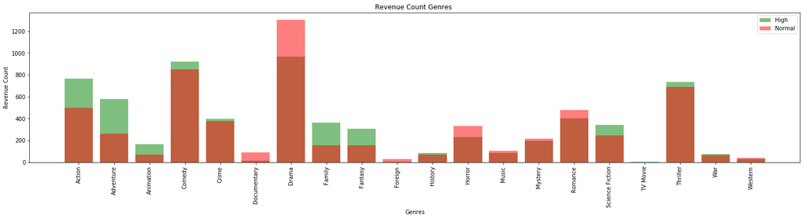

```python
column_high_reveune_bar('genres')
```

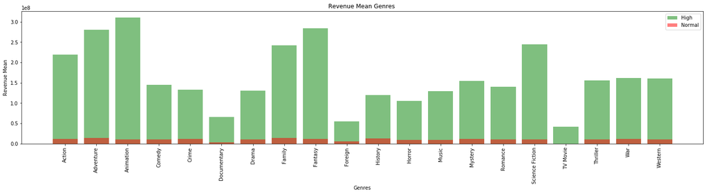

```python
column_high_reveune_bar('genres', operation='mean')
```

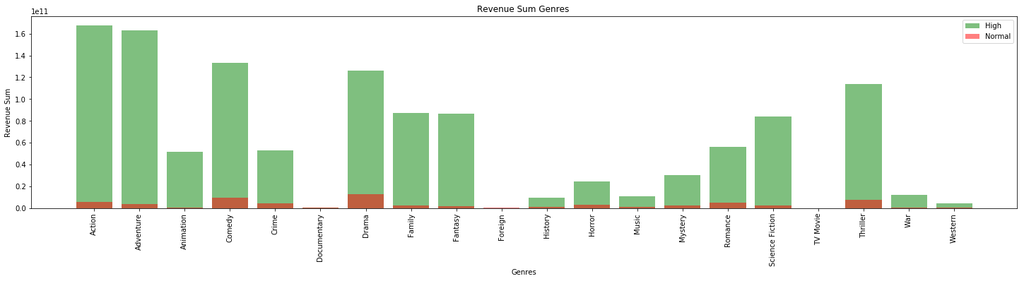

```python
column_high_reveune_bar('genres', operation='sum')
```

It's like there's some genders with higher reveune then others.

#### Is there a Companie association with reveune?

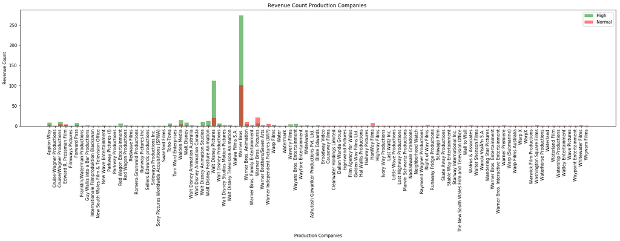

```python
column_high_reveune_bar('production_companies','wa')
```

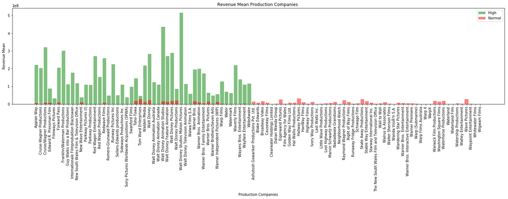

```python
column_high_reveune_bar('production_companies','wa', 'mean')
```

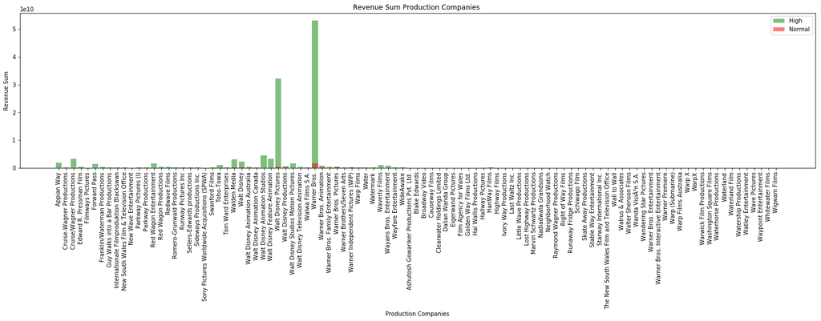

```python
column_high_reveune_bar('production_companies','wa', 'sum')
```

Some companies have more probability to have better revenue then others

#### Is there a Cast association with reveune?

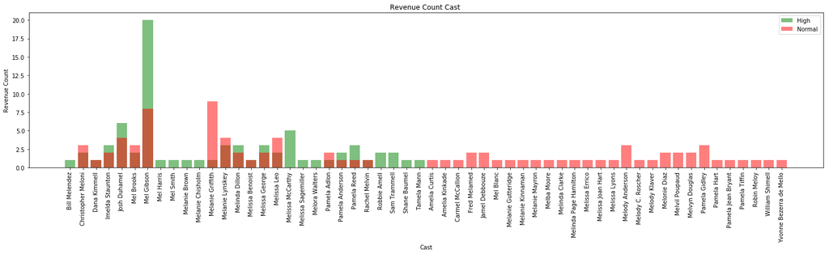

```python
column_high_reveune_bar('cast', 'mel')
```

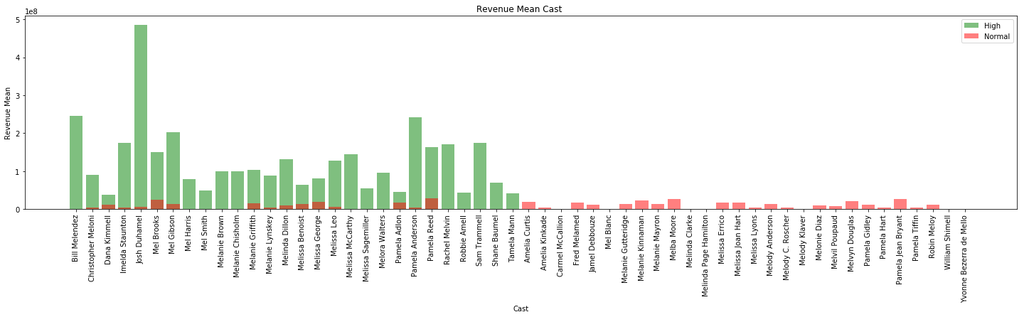

```python
column_high_reveune_bar('cast', 'mel', 'mean')
```

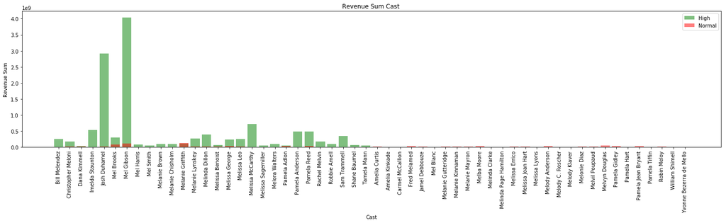

```python
column_high_reveune_bar('cast', 'mel', 'sum')
```

Some actors is more used in movies with higher revenue

#### Is there a Director association with reveune?

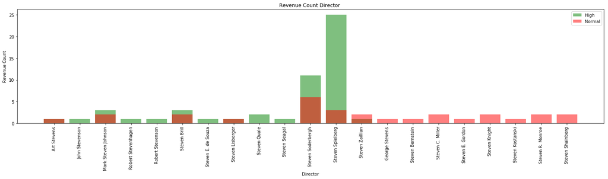

```python
column_high_reveune_bar('director', 'steven')
```

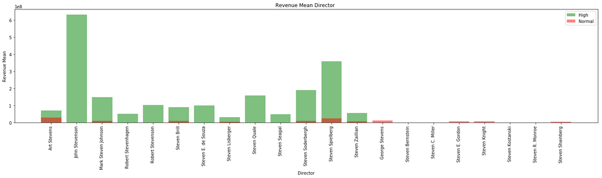

```python
column_high_reveune_bar('director', 'steven', 'mean')
```

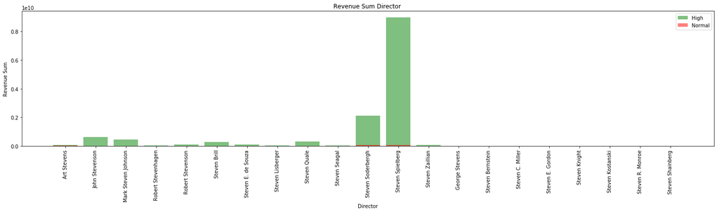

```python
column_high_reveune_bar('director', 'steven', 'sum')
```

Some directors have done more higher reveune then others.

#### What's the association with Numeric values?

First a quick analyze with the raw numbers

```python
def high_revenue_values_by(column):
    if check_key_error(df_not_zero_revenue, column):
        return
    df_high_revenue_grupby = df_not_zero_revenue.groupby('high_revenue')
    print('Mean: {}\n'.format(df_high_revenue_grupby[column].mean()))
    print('Sum: {}\n'.format(df_high_revenue_grupby[column].sum()))
    print('Std: {}\n'.format(df_high_revenue_grupby[column].std()))
    print('Median: {}\n'.format(df_high_revenue_grupby[column].median()))
```

```python
high_revenue_values_by('popularity')
```

```
Mean: high_revenue
False    0.550707
True     1.539919
Name: popularity, dtype: float64

Sum: high_revenue
False    1336.013975
True     3732.764738
Name: popularity, dtype: float64

Std: high_revenue
False    0.473062
True     1.723226
Name: popularity, dtype: float64

Median: high_revenue
False    0.444901
True     1.097011
Name: popularity, dtype: float64
```

```python
high_revenue_values_by('budget')
```

```
Mean: high_revenue
False    2.299469e+07
True     5.142069e+07
Name: budget, dtype: float64

Sum: high_revenue
False    5.578513e+10
True     1.246437e+11
Name: budget, dtype: float64

Std: high_revenue
False    1.848595e+07
True     4.567945e+07
Name: budget, dtype: float64

Median: high_revenue
False    2.200000e+07
True     3.720183e+07
Name: budget, dtype: float64
```

```python
high_revenue_values_by('vote_average')
```

```
Mean: high_revenue
False    6.027246
True     6.270380
Name: vote_average, dtype: float64

Sum: high_revenue
False    14622.1
True     15199.4
Name: vote_average, dtype: float64

Std: high_revenue
False    0.827798
True     0.749360
Name: vote_average, dtype: float64

Median: high_revenue
False    6.1
True     6.3
Name: vote_average, dtype: float64
```

```python
high_revenue_values_by('vote_count')
```

```
Mean: high_revenue
False    117.335944
True     755.358911
Name: vote_count, dtype: float64

Sum: high_revenue
False     284657
True     1830990
Name: vote_count, dtype: int64

Std: high_revenue
False     216.850016
True     1025.013159
Name: vote_count, dtype: float64

Median: high_revenue
False     53.0
True     375.5
Name: vote_count, dtype: float64
```

#### What's the Popularity association?

```python
def quantile_df_below_filter(df, column, interpolation='lower'):
    column_interpolation = df_not_zero_revenue[column].quantile(interpolation=interpolation)
    return df[df[column]<column_interpolation]
```

```python
def quantile_df_above_filter(df, column, percentile, interpolation='higher'):
    column_interpolation= df_not_zero_revenue[column].quantile(interpolation=interpolation)
    return df[df[column]>=column_interpolation]
```

```python
def revenue_bar(column, filter_func=quantile_df_above_filter, interpolation='higher', explanation_to_title='above higher'):
    if check_key_error(df_high_revenue, column):
        return
    plt_size(5,5)
    bar_width = 0.3

    df_high_to_show = filter_func(df_high_revenue, column, interpolation)
    df_normal_to_show = filter_func(df_normal_revenue, column, interpolation)

    plt.bar(high_revenue_legend[0], df_high_to_show[column].sum(), bar_width, color='green')
    plt.bar(high_revenue_legend[1], df_normal_to_show[column].sum(), bar_width, color='red')

    plt.xlabel('Revenue type')
    plt.ylabel('{} Sum'.format(column.replace('_',' ').title()))

    plt.title(title_chart('Revenue {}'.format(explanation_to_title), column))
    plt.legend(high_revenue_legend)
    plt.show();
```

```python
def show_mult_chart(chart_func, column):
    chart_func(column)
    chart_func(column, quantile_df_below_filter, explanation_to_title='below lower')
```

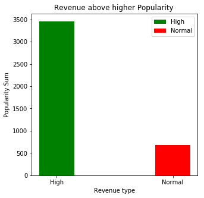

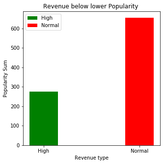

```python
show_mult_chart(revenue_bar,'popularity')
```

```python
def revenue_hist(column, filter_func=quantile_df_above_filter, interpolation='higher', explanation_to_title='above higher'):
    if check_key_error(df_high_revenue, column):
        return
    plt_size(5,5)

    df_high_to_show = filter_func(df_high_revenue, column, interpolation)
    df_normal_to_show = filter_func(df_normal_revenue, column, interpolation)

    plt.hist(df_high_to_show[column],alpha=0.5, color='green')
    plt.hist(df_normal_to_show[column], alpha=0.5, color='red')

    plt.ylabel('Frequency of {}'.format(column.replace('_',' ').title()))
    plt.xlabel('Popularity')

    plt.title(title_chart('Revenue {}'.format(explanation_to_title), column))
    plt.legend(high_revenue_legend)
    plt.show();
```

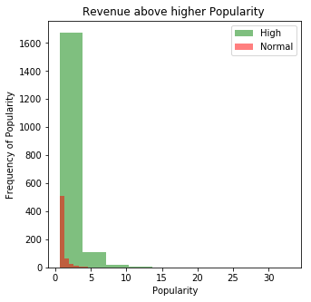

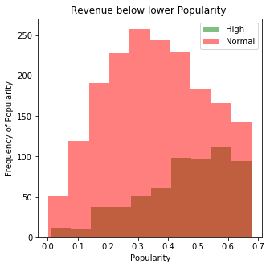

```python
show_mult_chart(revenue_hist,'popularity')
```

```python
def revenue_pie(column, filter_func=quantile_df_above_filter, interpolation='higher', explanation_to_title='above higher'):
    if check_key_error(df_high_revenue, column):
        return
    plt_size(5,5)
    figure, ax = plt.subplots()
    high_revenue_legend = np.array(['Normal','High'])

    data_to_show = filter_func(df_not_zero_revenue, column, interpolation)
    data_to_show = data_to_show.groupby('high_revenue')[column].sum()

    # Data to calculate the percent of the pie and format it to show
    sum_to_label = data_to_show.sum()

    # Calculate the percentile of each value
    labels = (data_to_show/sum_to_label)*100
    labels = labels.map(lambda n: '{:.2f}%'.format(n))
    plt.ylabel('{} Percent'.format(column.replace('_',' ').title()))
    plt.xlabel('Revenue type')

    ax.pie(data_to_show, colors= ['red','green'], labels=labels)
    plt.title(title_chart('Revenue {}'.format(explanation_to_title), column))
    plt.legend(high_revenue_legend, loc=0)
    plt.show();
```

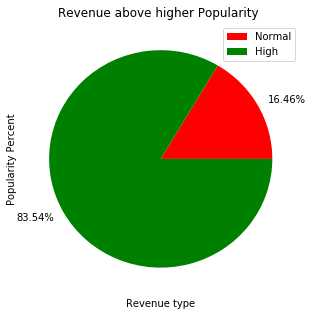

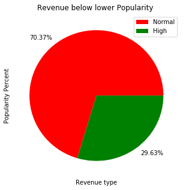

```python
show_mult_chart(revenue_pie, 'popularity')
```

#### What's the Budget association?

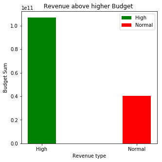

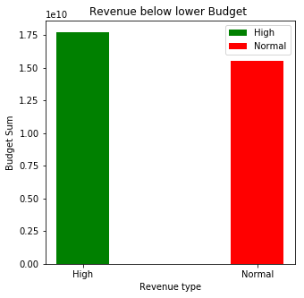

```python
show_mult_chart(revenue_bar, 'budget')
```

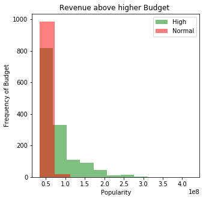

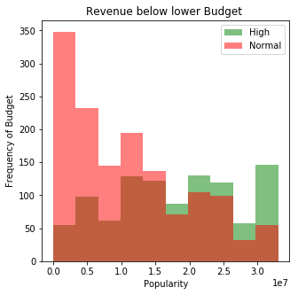

```python
show_mult_chart(revenue_hist, 'budget')
```

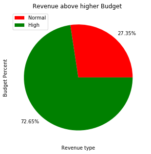

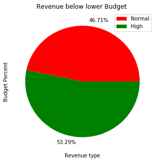

```python
show_mult_chart(revenue_pie, 'budget')
```

#### What's the Vote Average association?

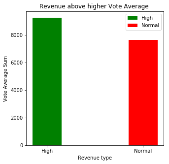

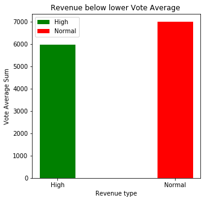

```python
show_mult_chart(revenue_bar, 'vote_average')
```

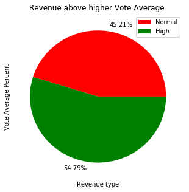

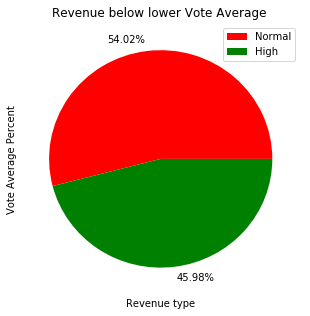

```python
show_mult_chart(revenue_pie, 'vote_average')
```

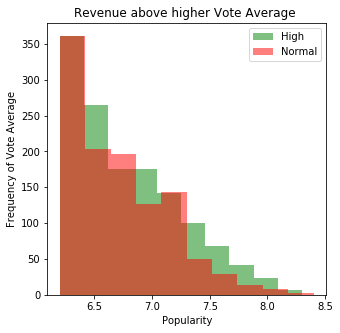

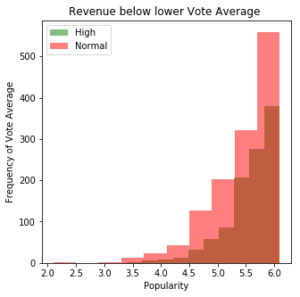

```python
show_mult_chart(revenue_hist, 'vote_average')
```

#### What's the Vote count association?

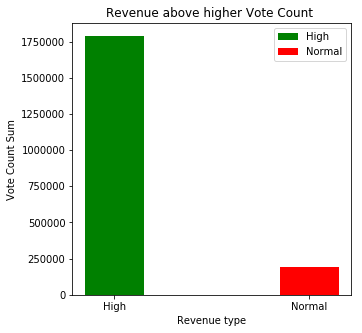

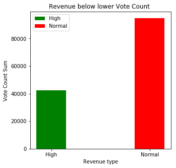

```python
show_mult_chart(revenue_bar, 'vote_count')
```

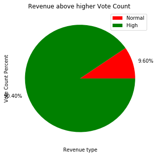

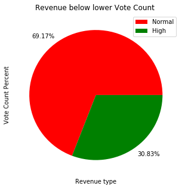

```python
show_mult_chart(revenue_pie, 'vote_count')
```

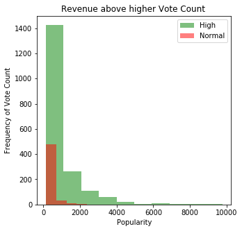

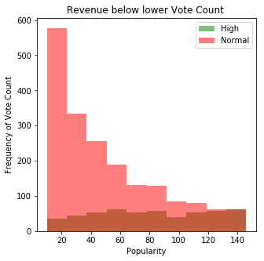

```python
show_mult_chart(revenue_hist, 'vote_count')
```

## Conclusions

### What kinds of properties are associated with movies that have high revenues?

With the data without zero reveune we can see that: vote count, budget, popularity maybe have some association with high revenues movies. And some companies, directors and cast is offten in a high revenues movies.

# Limitations

This dataset we have problem with some tuples that some columns have NULL values the columns are: genres, production_companies or cast.

There's a lot of zero values in reveune or budget columns in the dataset, so it's compromise the analyze.

```python
from subprocess import call
call(['python','-m','nbconvert','tmdb-movie-data-analysis.ipynb'])
```

```
1
```